# PROJECT 2: PROPERTY TAX ASSESSMENT

Loic Wega

Last compiled on April 20, 2025 at 10:02 PM - CDT

# 1 **INTRODUCTION**

Property tax is a form of revenue that the county uses to fund municipal operations. A tax assessor estimates the value of the property (land plus house), and then tax is levied as a percentage of the assessed value, less any exemptions. The problem is that the assessed value of property isn’t very scientific, rather the tax assessor simply adjusts the value of the property based on what he/she feels is right. Because of this, homeowners have the chance to appeal their assessment to the assessor, even taking it to court if necessary.

This project is concerned with the assessed value of property at **6321 88th Street in Lubbock**, Texas, specifically whether the assessment is justified given the assessed property of other homes in the neighborhood.

We will use the muliple linear regression equation $y=b_0+b_1X_1+b_2X_2+b_3X_3+.....b_nX_n$ and least squares estimates coefficients to evaluate our model

with:

$b_0= intercept$

$b_1, b_2, b_3...b_n$ are all slopes values

The data that is used for this project may be collected by following this link [DataSet_Property_Assessment](https://github.com/weglo/Data-Analytics-course/blob/main/Dataset_Property_assesment.csv)

The Initial breakdown of key variables is like in the table below as follows the information on the website ( https://lubbockcad.org/ )

| Variable | Explanation |
| --- | --- |
| 2025 Market Value | Total value of property appraisal (house+land) |
| Total Improvement Market Value | Total value of house appraisal |
| Total Land Market Value | Total value of land appraisal |
| Homestead Cap Loss | Represents a discount only in the current tax year if the appraised value from the previous year went up by more than 10% |
| Total Main Area (Sq. Ft.) | Total square footage of house |
| Main Area (Sq. Ft.) | Total square footage of heated house area |
| Main Area (Value) | Total value of heated house area |
| Garage (Sq. Ft.) | Total square footage of non-heated house area |
| Garage (Value) | Total value of non-heated house area |
| Land (Sq. Ft.) | Total square footage of land |

## 1.1 **ASSUMPTIONS**

Following those assumptions when collecting the data:

We end up with the following breakdown of our variables

| **Predicted variable** | **Predictors variables** |
| --- | --- |
|  | ” TOTAL MAIN AREA (Sq. Ft) ” |
| ” 2025 Market Value ” | ” MAIN AREA (Sq. Ft) ” |
|  | ” GARAGE ( Sq. Ft) ” |
|  | ” LAND (Sq. Ft) ” |

## 1.2 **STEPS OF ANALYSIS**

- Data Loading and Initial Analysis: Importing and summarizing the dataset to assess completeness and structure.
- Exploratory Data Analysis (EDA): Conducted to visualize the overall structure of the dataset, examine the distribution of the response variable, and explore correlations among predictor variables.
- Built an initial regression model and examined both the estimated coefficients and the Variance Inflation Factors (VIFs) to check for multicollinearity.
- Tested various combinations of predictor variables and refined our models to find the most accurate and reliable one.
- Using the final model make the prediction of the market value of property “6321 88th street” and compare to the actual value

# 2 **EXPLORATORY DATA ANALYSIS (EDA)**

In this part we will do the initial analysis of our dataset examine its basic structure, visually assess the distribution of the response variable and identify relationships between predictors. This will guide us and help us to better understand our datas.

## 2.1 **Data structure**

```r
# Load our dataset in R
dataproperty <- read.csv("https://raw.githubusercontent.com/weglo/Data-Analytics-course/refs/heads/main/Dataset_Property_assesment.csv")
colnames(dataproperty) <- c("Market_value_2025", "Total_main_area", "Main_area", "Garage", "Land")

# Structure and summary
head(dataproperty)
```

```
##   Market_value_2025 Total_main_area Main_area Garage  Land
## 1            735026            3462      3192   1063 10000
## 2            663907            3226      3226   1078 10463
## 3            569992            3036      3036    965 10000
## 4            602427            3277      2877    909 10625
## 5            550119            2582      2582    942  7749
## 6            709604            3147      3147    875 11633
```

```r
str(dataproperty)
```

```
## 'data.frame':    34 obs. of  5 variables:
##  $ Market_value_2025: int  735026 663907 569992 602427 550119 709604 480134 467935 610318 534991 ...
##  $ Total_main_area  : int  3462 3226 3036 3277 2582 3147 2842 2382 2925 2806 ...
##  $ Main_area        : int  3192 3226 3036 2877 2582 3147 2842 2382 2925 2806 ...
##  $ Garage           : int  1063 1078 965 909 942 875 970 520 957 552 ...
##  $ Land             : int  10000 10463 10000 10625 7749 11633 8206 7749 9821 8057 ...
```

```r
colSums(is.na(dataproperty))
```

```
## Market_value_2025   Total_main_area         Main_area            Garage
##                 0                 0                 0                 0
##              Land
##                 0
```

### 2.1.1 **Interpretation**

The dataset contains variables such as Main_area, Garage, Total_main_area, and Land that can influence 2025_Market_Value. No missing values were detected, and the data types are appropriate for analysis.

## 2.2 **Response value disribution**

lets explore the response variable distribution

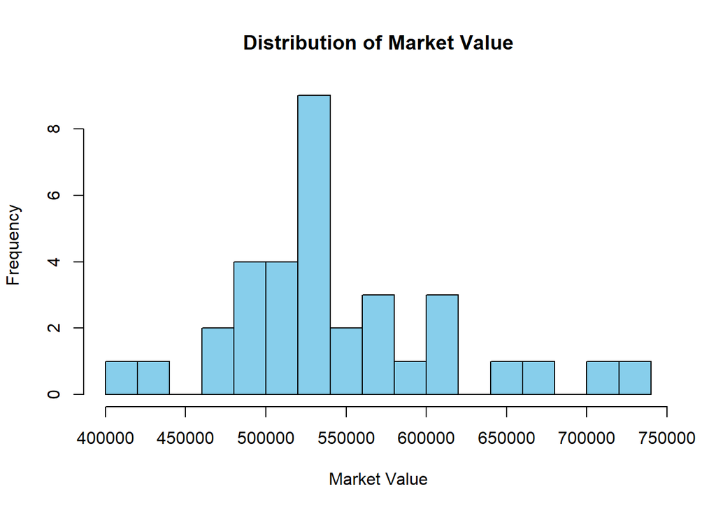

```r
# Histogram of market value
hist(dataproperty$Market_value_2025,
     main = "Distribution of Market Value",
     xlab = "Market Value",
     col = "skyblue", breaks = 20)
```

### 2.2.1 **Interpretation**

The market value distribution shows a **slight right skew**, possibly due to high-value outliers.

## 2.3 **Correlation between predictor**

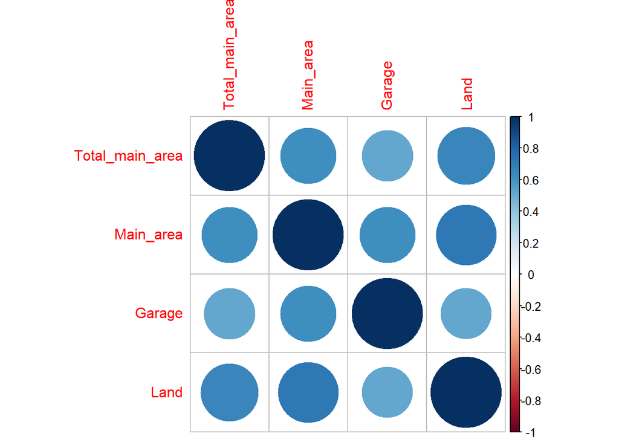

```r
# Correlation matrix
library(tidyverse)
library(corrplot)
data <- dataproperty[-1]
corrplot(cor(data %>% select_if(is.numeric)), method = "circle")
```

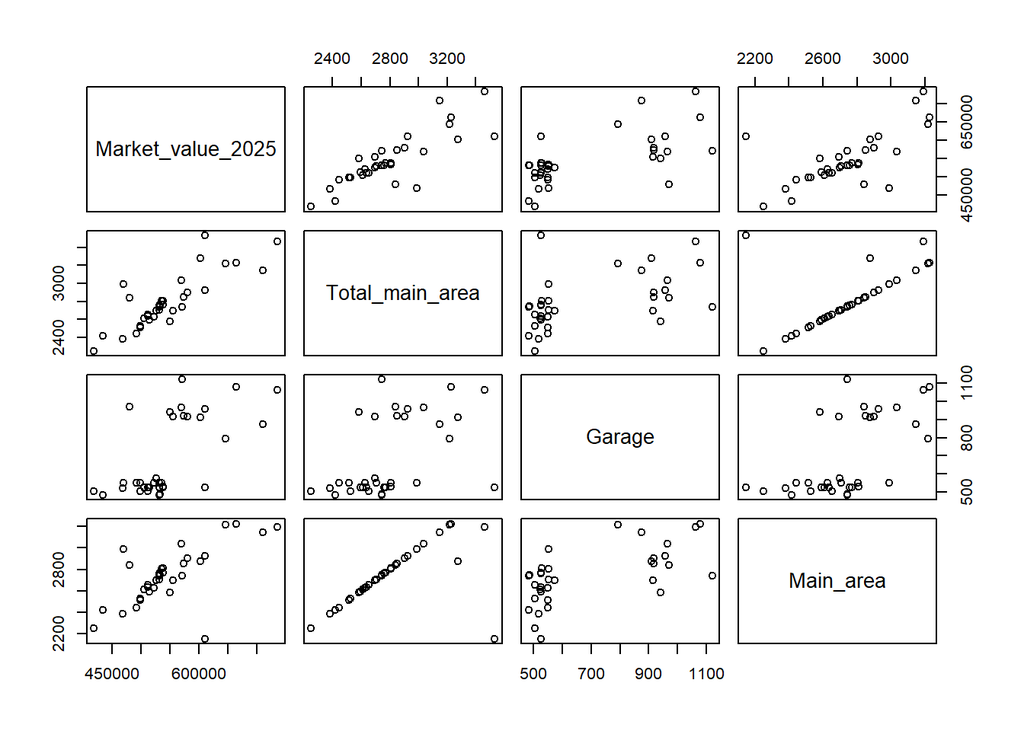

```r
# Pairwise scatterplots (optional)
pairs(~ Market_value_2025 + Total_main_area + Garage + Main_area, data = dataproperty)
```

### 2.3.1 **Interpretation**

The pairwise visual analysis confirms a **positive linear relationship** between size-related variables and market value.

# 3 **REGRESSION MODEL AND ANALYSIS**

## 3.1 **Initial regression model and VIF check**

lets fit a full regression model with all the predictor variables and evaluate multicollinearity

```r
# Fit the initial model
library(car)
model_initial <- lm(Market_value_2025 ~ Total_main_area + Main_area + Garage + Land, data = dataproperty)
summary(model_initial)
```

```
##
## Call:
## lm(formula = Market_value_2025 ~ Total_main_area + Main_area +
##     Garage + Land, data = dataproperty)
##
## Residuals:
##    Min     1Q Median     3Q    Max
## -89907   2088   9016  12713  59906
##
## Coefficients:
##                 Estimate Std. Error t value Pr(>|t|)
## (Intercept)      3465.85   74238.09   0.047 0.963084
## Total_main_area   121.66      27.45   4.431 0.000123 ***
## Main_area          14.92      36.36   0.410 0.684517
## Garage             73.01      34.80   2.098 0.044759 *
## Land               13.11       7.23   1.814 0.080080 .
## ---
## Signif. codes:  0 '***' 0.001 '**' 0.01 '*' 0.05 '.' 0.1 ' ' 1
##
## Residual standard error: 33570 on 29 degrees of freedom
## Multiple R-squared:  0.7967, Adjusted R-squared:  0.7687
## F-statistic: 28.42 on 4 and 29 DF,  p-value: 1.163e-09
```

```r
# Check Variance Inflation Factors
vif(model_initial)
```

```
## Total_main_area       Main_area          Garage            Land
##        1.975669        2.583788        1.697125        2.465179
```

the equation for the initial model is :

$$y=3465.85 + 121.66X_1 + 14.92X_2 + 73.01X_3 + 13.11X_4$$

$B_1 =121.66$

$B_2 =14.92$

$B_3 = 73.01$

$B_4 = 13.11$

## 3.2 **Outliers, leverages and influences**

In this part we are going to evaluate whether we have properties with unusually high or low predictors values ( Total_main_area, Main_area, Garage, Land ) given the Initial model.

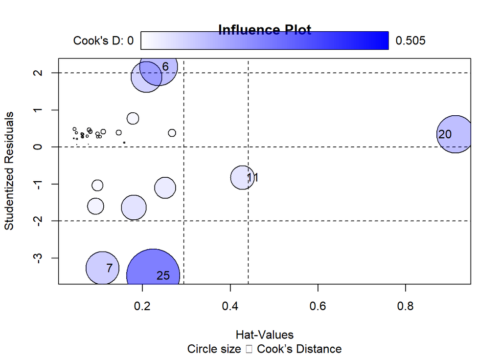

```
##       StudRes       Hat     CookD
## 6   2.1682997 0.2361676 0.2578225
## 7  -3.2803401 0.1090277 0.1970369
## 11 -0.8242488 0.4277808 0.1027149
## 20  0.3416426 0.9134231 0.2540254
## 25 -3.4792559 0.2239673 0.5052477
```

```r
# Load necessary package
library(car)

# Plot 1: Influence Plot (Outliers + Leverage + Cook's Distance)
influencePlot(model_initial,
              id.method = "identify",
              main = "Influence Plot",
              sub = "Circle size ∝ Cook’s Distance")
```

## 3.3 **Interpretation**

### 3.3.1 **Summary Interpretation**

#### 3.3.1.1 **VIF (Variance Inflation Factor ) interpretation**

| **Predictor** | **VIF** | **Interpretation** |
| --- | --- | --- |
| Total_main_area | 1.98 | No multicollinearity concern |
| Main_area | 2.58 | Acceptable, but relatively high could be overlapping with Total_main_area |
| Garage | 1.70 | Low multicollinearity |
| Land | 2.47 | Acceptable |

### 3.3.2 Outliers, leverages and influences interpretation

- **observation 25** is the most problematic data point; very large negative residual it’s far below what the model predicts; medium leverage and large cook’s distance, it’s pulling the model down
- **Observation 7** is also a strong outlier with moderate influence.
- **Observation 20** isn’t an outlier but has **very high leverage**, meaning its **predictors are extreme** maybe an unusually large house or land area.
- **Observation 11** has **high leverage** but doesn’t appear to distort the model much (low Cook’s Distance)
- **Observation 6** is a moderate outlier.